# SK_01_BOND_ISSUE_DATE

Date issued · Date report

## Overview

**Description**

Form990 Schedule KPart I - Date issued

**Table**

`SK-P01-T01-BOND-ISSUES` (many)

**Location code**

`SCHED-K-PART-01-COL-D`

**Family**

`SCHED-K-PART-01-COL-D`

**Data type**

date (xsd: DateType)

**Scope**

PC

**Status**

unreviewed

2

xpaths mapped (2 observed)

88,938

filings with a value

2009–2024

tax years observed

2

open flags (0 errors)

## Flags

| Severity | Flag | Xpath | Detail |
| --- | --- | --- | --- |
| ⓘ info | `MANY_NOT_REPEATING` | IRS990ScheduleK/TaxExemptBondsIssuesGrp/BondIssuedDt | many-to-one table, but 57% of values sit in no repeating element |
| ⓘ info | `MANY_NOT_REPEATING` | IRS990ScheduleK/Form990ScheduleKPartI/DateIssued | many-to-one table, but 57% of values sit in no repeating element |

## Xpaths

All mapped xpaths (under /Return/ReturnData or /Return/ReturnHeader), oldest first. Charts label each series by its xpath.

| Xpath | Form | First year | Last year | Versions | Filings | Repeats in |
| --- | --- | --- | --- | --- | --- | --- |
| IRS990ScheduleK/Form990ScheduleKPartI/DateIssued | Sched K | 2009 | 2012 | 18 | 19,645 | 41.1% |
| IRS990ScheduleK/TaxExemptBondsIssuesGrp/BondIssuedDt | Sched K | 2013 | 2024 | 37 | 69,293 | 40.6% |

## Coverage

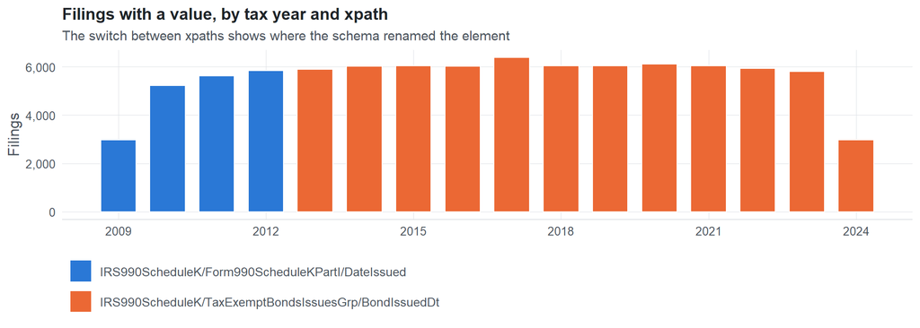

**Table view**

Table view: filings by tax year and series

| Tax year | IRS990ScheduleK/Form990ScheduleKPartI/DateIssued | IRS990ScheduleK/TaxExemptBondsIssuesGrp/BondIssuedDt |
| --- | --- | --- |
| 2009 | 2,964 | 0 |
| 2010 | 5,216 | 0 |
| 2011 | 5,622 | 0 |
| 2012 | 5,843 | 0 |
| 2013 | 0 | 5,900 |
| 2014 | 0 | 6,020 |
| 2015 | 0 | 6,038 |
| 2016 | 0 | 6,016 |
| 2017 | 0 | 6,379 |
| 2018 | 0 | 6,041 |
| 2019 | 0 | 6,035 |
| 2020 | 0 | 6,121 |
| 2021 | 0 | 6,034 |
| 2022 | 0 | 5,936 |
| 2023 | 0 | 5,806 |
| 2024 | 0 | 2,967 |

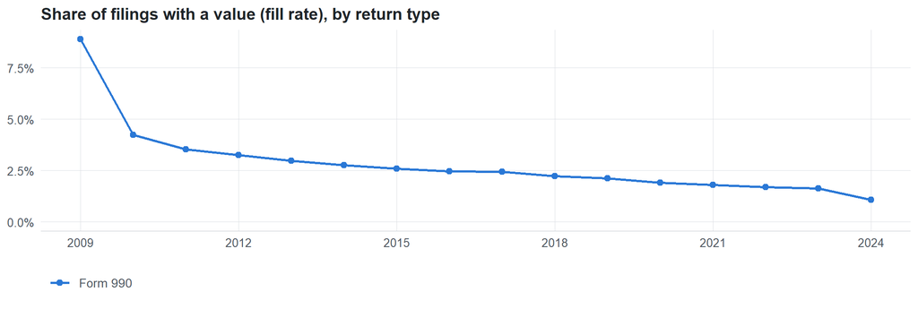

**Table view**

Table view: fill rate

| Tax year | Return type | Filings | All filings | Fill rate |
| --- | --- | --- | --- | --- |
| 2009 | Form 990 | 2,964 | 33,311 | 8.90% |
| 2010 | Form 990 | 5,216 | 123,025 | 4.24% |
| 2011 | Form 990 | 5,622 | 159,504 | 3.52% |
| 2012 | Form 990 | 5,843 | 179,688 | 3.25% |
| 2013 | Form 990 | 5,900 | 198,855 | 2.97% |
| 2014 | Form 990 | 6,020 | 218,619 | 2.75% |
| 2015 | Form 990 | 6,038 | 233,519 | 2.59% |
| 2016 | Form 990 | 6,016 | 243,903 | 2.47% |
| 2017 | Form 990 | 6,379 | 261,612 | 2.44% |
| 2018 | Form 990 | 6,041 | 271,442 | 2.23% |
| 2019 | Form 990 | 6,035 | 283,694 | 2.13% |
| 2020 | Form 990 | 6,121 | 320,342 | 1.91% |
| 2021 | Form 990 | 6,034 | 336,480 | 1.79% |
| 2022 | Form 990 | 5,936 | 349,055 | 1.70% |
| 2023 | Form 990 | 5,806 | 354,768 | 1.64% |
| 2024 | Form 990 | 2,967 | 277,298 | 1.07% |

## Repeating groups

Table cardinality in the concordance: **many**. 2 of 2 observed xpaths repeat within a filing.

Repeating element each xpath was observed in (from the raw indexed xpath)

| Xpath | Repeating element | Filings (summed over years) |
| --- | --- | --- |
| IRS990ScheduleK/Form990ScheduleKPartI/DateIssued | (none) | 11544 |
| IRS990ScheduleK/Form990ScheduleKPartI/DateIssued | IRS990ScheduleK | 469 |
| IRS990ScheduleK/Form990ScheduleKPartI/DateIssued | IRS990ScheduleK/Form990ScheduleKPartI | 8083 |
| IRS990ScheduleK/TaxExemptBondsIssuesGrp/BondIssuedDt | (none) | 41078 |
| IRS990ScheduleK/TaxExemptBondsIssuesGrp/BondIssuedDt | IRS990ScheduleK | 2252 |
| IRS990ScheduleK/TaxExemptBondsIssuesGrp/BondIssuedDt | IRS990ScheduleK/TaxExemptBondsIssuesGrp | 28176 |

## Values

| Result | Check | Detail |
| --- | --- | --- |
| ✓ pass | One date format | 100.0% use date (YYYY-MM-DD) |
| ⓘ info | Dates after the tax year | 4 of 16 tax years contain a date more than 3 years later (e.g. TY2011: 2016-04-26) |
| ✓ pass | Dates before 1900 | no dates before 1900 |

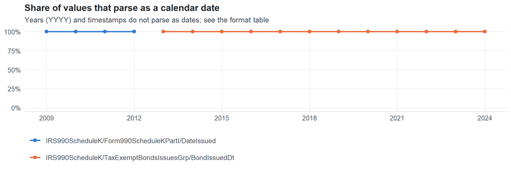

Formats (value shapes: 9 = digit, A = letter)

| Series | Shape | Format | Filings | Share |
| --- | --- | --- | --- | --- |
| IRS990ScheduleK/Form990ScheduleKPartI/DateIssued | 9999-99-99 | date (YYYY-MM-DD) | 19,645 | 100.0% |
| IRS990ScheduleK/TaxExemptBondsIssuesGrp/BondIssuedDt | 9999-99-99 | date (YYYY-MM-DD) | 69,293 | 100.0% |

**Table view**

Earliest and latest value by tax year

| Series | Tax year | Filings | Earliest | Latest |
| --- | --- | --- | --- | --- |
| IRS990ScheduleK/Form990ScheduleKPartI/DateIssued | 2009 | 2,964 | 1920-01-19 | 2011-05-13 |
| IRS990ScheduleK/Form990ScheduleKPartI/DateIssued | 2010 | 5,216 | 1907-11-29 | 2011-11-10 |
| IRS990ScheduleK/Form990ScheduleKPartI/DateIssued | 2011 | 5,622 | 1907-11-29 | 2016-04-26 |
| IRS990ScheduleK/Form990ScheduleKPartI/DateIssued | 2012 | 5,843 | 1907-11-29 | 2013-11-30 |
| IRS990ScheduleK/TaxExemptBondsIssuesGrp/BondIssuedDt | 2013 | 5,900 | 1907-11-29 | 2015-11-05 |
| IRS990ScheduleK/TaxExemptBondsIssuesGrp/BondIssuedDt | 2014 | 6,020 | 1920-09-29 | 2016-10-18 |
| IRS990ScheduleK/TaxExemptBondsIssuesGrp/BondIssuedDt | 2015 | 6,038 | 1921-06-01 | 2020-10-31 |
| IRS990ScheduleK/TaxExemptBondsIssuesGrp/BondIssuedDt | 2016 | 6,016 | 1917-04-26 | 2103-11-18 |
| IRS990ScheduleK/TaxExemptBondsIssuesGrp/BondIssuedDt | 2017 | 6,379 | 1994-12-01 | 2020-12-29 |
| IRS990ScheduleK/TaxExemptBondsIssuesGrp/BondIssuedDt | 2018 | 6,041 | 1993-07-07 | 2020-12-29 |
| IRS990ScheduleK/TaxExemptBondsIssuesGrp/BondIssuedDt | 2019 | 6,035 | 1929-12-23 | 2020-12-29 |
| IRS990ScheduleK/TaxExemptBondsIssuesGrp/BondIssuedDt | 2020 | 6,121 | 1998-01-01 | 2021-12-23 |
| IRS990ScheduleK/TaxExemptBondsIssuesGrp/BondIssuedDt | 2021 | 6,034 | 1928-02-28 | 2022-09-30 |
| IRS990ScheduleK/TaxExemptBondsIssuesGrp/BondIssuedDt | 2022 | 5,936 | 1929-11-07 | 2027-11-01 |
| IRS990ScheduleK/TaxExemptBondsIssuesGrp/BondIssuedDt | 2023 | 5,806 | 1998-01-01 | 2025-06-01 |
| IRS990ScheduleK/TaxExemptBondsIssuesGrp/BondIssuedDt | 2024 | 2,967 | 1998-01-01 | 2025-06-27 |

## Examples

| Tax year | Return | Xpath | Organization | Value | Source |
| --- | --- | --- | --- | --- | --- |
| 2024 | 990 | IRS990ScheduleK/TaxExemptBondsIssuesGrp/BondIssuedDt | THE CLEVELAND CLINIC FOUNDATION | 2008-10-15 | [XML](https://gt990datalake-rawdata.s3.amazonaws.com/EfileData/XmlFiles/202513189349302136_public.xml) |
| 2023 | 990 | IRS990ScheduleK/TaxExemptBondsIssuesGrp/BondIssuedDt | RINGLING COLLEGE OF ART AND DESIGN INC | 2017-11-01 | [XML](https://gt990datalake-rawdata.s3.amazonaws.com/EfileData/XmlFiles/202501049349302265_public.xml) |
| 2022 | 990 | IRS990ScheduleK/TaxExemptBondsIssuesGrp/BondIssuedDt | LUTHERAN HOME OF JAMAICA PLAIN INC | 2017-06-12 | [XML](https://gt990datalake-rawdata.s3.amazonaws.com/EfileData/XmlFiles/202431279349301533_public.xml) |
| 2021 | 990 | IRS990ScheduleK/TaxExemptBondsIssuesGrp/BondIssuedDt | MARY ANN MORSE HEALTHCARE CORP | 2010-11-19 | [XML](https://gt990datalake-rawdata.s3.amazonaws.com/EfileData/XmlFiles/202232659349301608_public.xml) |
| 2020 | 990 | IRS990ScheduleK/TaxExemptBondsIssuesGrp/BondIssuedDt | RIDGEVIEW CLASSICAL SCHOOLS | 2014-06-30 | [XML](https://gt990datalake-rawdata.s3.amazonaws.com/EfileData/XmlFiles/202211329349306866_public.xml) |
| 2019 | 990 | IRS990ScheduleK/TaxExemptBondsIssuesGrp/BondIssuedDt | ST ANNE’S EPISCOPAL SCHOOL INC | 2009-11-02 | [XML](https://gt990datalake-rawdata.s3.amazonaws.com/EfileData/XmlFiles/202101269349301820_public.xml) |
| 2018 | 990 | IRS990ScheduleK/TaxExemptBondsIssuesGrp/BondIssuedDt | THE GAVIN FOUNDATION INC | 2017-11-01 | [XML](https://gt990datalake-rawdata.s3.amazonaws.com/EfileData/XmlFiles/202040879349300824_public.xml) |
| 2017 | 990 | IRS990ScheduleK/TaxExemptBondsIssuesGrp/BondIssuedDt | Advance Education Inc | 2010-01-25 | [XML](https://gt990datalake-rawdata.s3.amazonaws.com/EfileData/XmlFiles/201911359349306136_public.xml) |
| 2016 | 990 | IRS990ScheduleK/TaxExemptBondsIssuesGrp/BondIssuedDt | LAFAYETTE COLLEGE | 2013-11-26 | [XML](https://gt990datalake-rawdata.s3.amazonaws.com/EfileData/XmlFiles/201811359349307786_public.xml) |
| 2015 | 990 | IRS990ScheduleK/TaxExemptBondsIssuesGrp/BondIssuedDt | STAPELEY HALL | 2005-09-08 | [XML](https://gt990datalake-rawdata.s3.amazonaws.com/EfileData/XmlFiles/201623199349306982_public.xml) |
| 2014 | 990 | IRS990ScheduleK/TaxExemptBondsIssuesGrp/BondIssuedDt | ARAPAHOE HOUSE INC | 2004-05-27 | [XML](https://gt990datalake-rawdata.s3.amazonaws.com/EfileData/XmlFiles/201611179349300921_public.xml) |
| 2013 | 990 | IRS990ScheduleK/TaxExemptBondsIssuesGrp/BondIssuedDt | FSU Financial Assistance Inc | 2003-03-25 | [XML](https://gt990datalake-rawdata.s3.amazonaws.com/EfileData/XmlFiles/201511339349304821_public.xml) |

## Reviewer checklist

- The definition matches the form line and instructions for every xpath’s schema years.
- Every xpath pooled here measures the same thing on the 990 and 990-EZ (close enough for analysis).
- The coverage chart has no unexplained gaps or jumps between tax years.
- Each open flag is fixed, or accepted with a note in validation_log.csv.
- The format is consistent (date, year or timestamp) and matches the data type.
- The date is on the expected side of the tax period (e.g. signature date after the period ends, formation year before it).
- Extreme earliest/latest values are data-entry errors, not a mapping problem.

Record the review as a row in `inst/extdata/src/validation_log.csv` (variable_name, reviewer, date, status, note). Evidence built 2026-09-23 17:09:04 MST from the ef2 DuckDB builds, TY2009–2024.